# Advanced Convolutional Neural Networks (CNN) - 2 - IMDB Movie reviews sentiment classification

- Objective: try different structures of CNNs

## CNN for Sentence Classification

- It is widely known that CNNs are good for snapshot-like data, like images
- However, CNNs are effectve for NLP tasks as well
- For more information, refer to:
  - Kim 2014 (http://emnlp2014.org/papers/pdf/EMNLP2014181.pdf)
  - Zhang et al 2015 (https://papers.nips.cc/paper/5782-character-level-convolutional-networks-for-text-classification.pdf)
- In this section, we perform sentence classification with CNNs (Kim 2014) </br>

[figure not shown]

- Pixels are made of embedding vectors of each word in a sentence
- Convolutions are performed based on word-level
- Classify each sentence as positive (1) or negative (0)

[figure not shown]

```python
import numpy as np
import matplotlib.pyplot as plt

from keras.datasets import imdb
from keras.preprocessing.sequence import pad_sequences
```

## Load Dataset

- IMDb Movie reviews sentiment classification Dataset
- Doc: https://keras.io/datasets/
- Parameter description
  - num_features: number of words to account for (i.e., only frequent n words are considered)
  - sequence_length: maximum number of words for a sentence (if sentence is too short, pad by zeros)
  - embedding_dimension: dimensionality of embedding space (i.e., dimensionality of vector representation for each word)

```python
num_features = 3000 # Consider 3000 words
sequence_length = 300 # Maximum sentence length in terms of words
embedding_dimension = 100 # word2vec dimension
```

```python
(X_train, y_train), (X_test, y_test) = imdb.load_data(num_words = num_features)
```

```
Downloading data from https://s3.amazonaws.com/text-datasets/imdb.npz
```

```python
# Pad the sentences with less length
X_train = pad_sequences(X_train, maxlen = sequence_length)
X_test = pad_sequences(X_test, maxlen = sequence_length)
```

```python
print(X_train.shape)
print(X_test.shape)
print(y_train.shape)
print(y_test.shape)
```

```
(25000, 300)
(25000, 300)
(25000,)
(25000,)
```

## 0. Basic CNN sentence classificationmodel

- Basic CNN using 1D convolution and pooling
- Known as "temporal convolution"

```python
from keras.models import Sequential
from keras.layers import Dense, Dropout, Activation, Conv1D, MaxPooling1D, Embedding, Flatten
from keras import optimizers
```

```python
def imdb_cnn():
    model = Sequential()

    # use Embedding layer to create vector representation of each word => it is fine-tuned every iteration
    model.add(Embedding(input_dim = 3000, output_dim = embedding_dimension, input_length = sequence_length))
    model.add(Conv1D(filters = 50, kernel_size = 5, strides = 1, padding = 'valid'))
    model.add(MaxPooling1D(2, padding = 'valid'))

    model.add(Flatten())

    model.add(Dense(10))
    model.add(Activation('relu'))
    model.add(Dense(1))
    model.add(Activation('sigmoid'))

    adam = optimizers.Adam(lr = 0.001)

    model.compile(loss='binary_crossentropy', optimizer=adam , metrics=['accuracy'])

    return model
```

```python
model = imdb_cnn()
```

```python
%%time
history = model.fit(X_train, y_train, batch_size = 50, epochs = 100, validation_split = 0.2, verbose = 0)
```

[output not shown]

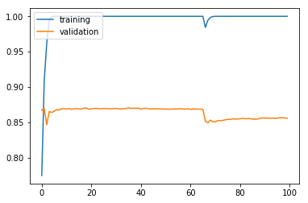

```python
plt.plot(history.history['acc'])
plt.plot(history.history['val_acc'])
plt.legend(['training', 'validation'], loc = 'upper left')
plt.show()
```

```python
results = model.evaluate(X_test, y_test)
```

```python
print('Test accuracy: ', results[1])
```

```
Test accuracy:  0.8556
```

## 1. Advanced CNN sentence classification model - 1

- Advanced CNN using 2D convolution and pooling
  - Embedding layer is "reshaped" to 4D to fit into 2D convolutional layer
- Perform global max pooling for each window

```python
from keras.layers import Reshape, Conv2D, GlobalMaxPooling2D
```

```python
def imdb_cnn_2():
    model = Sequential()

    model.add(Embedding(input_dim = 3000, output_dim = embedding_dimension, input_length = sequence_length))
    model.add(Reshape((sequence_length, embedding_dimension, 1), input_shape = (sequence_length, embedding_dimension)))
    model.add(Conv2D(filters = 50, kernel_size = (5, embedding_dimension), strides = (1,1), padding = 'valid'))
    model.add(GlobalMaxPooling2D())

    model.add(Dense(10))
    model.add(Activation('relu'))
    model.add(Dropout(0.3))
    model.add(Dense(10))
    model.add(Activation('relu'))
    model.add(Dropout(0.3))
    model.add(Dense(1))
    model.add(Activation('sigmoid'))

    adam = optimizers.Adam(lr = 0.001)

    model.compile(loss='binary_crossentropy', optimizer=adam , metrics=['accuracy'])

    return model
```

```python
model = imdb_cnn_2()
```

```python
%%time
history = model.fit(X_train, y_train, batch_size = 50, epochs = 100, validation_split = 0.2, verbose = 0)
```

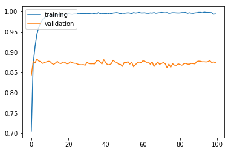

```python
plt.plot(history.history['acc'])
plt.plot(history.history['val_acc'])
plt.legend(['training', 'validation'], loc = 'upper left')
plt.show()
```

```python
results = model.evaluate(X_test, y_test)
```

```python
print('Test accuracy: ', results[1])
```

```
Test accuracy:  0.86628
```

## 3. Advanced CNN sentence classification model - 2

- Structure more similar to that proposed in **Kim 2014**
  - Three convoltion operations with different filter sizes are performed and their results are merged

```python
from keras.models import Model
from keras.layers import concatenate, Input
```

```python
filter_sizes = [3, 4, 5]
```

```python
def convolution():
    inn = Input(shape = (sequence_length, embedding_dimension, 1))
    convolutions = []
    # we conduct three convolutions & poolings then concatenate them.
    for fs in filter_sizes:
        conv = Conv2D(filters = 100, kernel_size = (fs, embedding_dimension), strides = 1, padding = "valid")(inn)
        nonlinearity = Activation('relu')(conv)
        maxpool = MaxPooling2D(pool_size = (sequence_length - fs + 1, 1), padding = "valid")(nonlinearity)
        convolutions.append(maxpool)

    outt = concatenate(convolutions)
    model = Model(inputs = inn, outputs = outt)

    return model
```

```python
def imdb_cnn_3():

    model = Sequential()
    model.add(Embedding(input_dim = 3000, output_dim = embedding_dimension, input_length = sequence_length))
    model.add(Reshape((sequence_length, embedding_dimension, 1), input_shape = (sequence_length, embedding_dimension)))

    # call convolution method defined above
    model.add(convolution())

    model.add(Flatten())
    model.add(Dense(10))
    model.add(Activation('relu'))
    model.add(Dropout(0.3))
    model.add(Dense(10))
    model.add(Activation('relu'))
    model.add(Dropout(0.3))
    model.add(Dense(1))
    model.add(Activation('sigmoid'))

    adam = optimizers.Adam(lr = 0.001)

    model.compile(loss='binary_crossentropy', optimizer=adam , metrics=['accuracy'])

    return model
```

```python
model = imdb_cnn_3()
```

```python
%%time
history = model.fit(X_train, y_train, batch_size = 50, epochs = 100, validation_split = 0.2, verbose = 0)
```

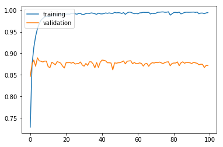

```python
plt.plot(history.history['acc'])
plt.plot(history.history['val_acc'])
plt.legend(['training', 'validation'], loc = 'upper left')
plt.show()
```

```python
results = model.evaluate(X_test, y_test)
```

```python
print('Test accuracy: ', results[1])
```

```
Test accuracy:  0.87284
```

## 3. Advanced CNN sentence classification model - 3

- Structure more similar to that proposed in **Kim 2014**
  - More techniques are applied to generate more stable results

```python
from keras.layers import BatchNormalization
```

```python
filter_sizes = [3, 4, 5]
```

```python
def convolution():
    inn = Input(shape = (sequence_length, embedding_dimension, 1))
    convolutions = []
    # we conduct three convolutions & poolings then concatenate them.
    for fs in filter_sizes:
        conv = Conv2D(filters = 100, kernel_size = (fs, embedding_dimension), strides = 1, padding = "valid")(inn)
        nonlinearity = Activation('relu')(conv)
        maxpool = MaxPooling2D(pool_size = (sequence_length - fs + 1, 1), padding = "valid")(nonlinearity)
        convolutions.append(maxpool)

    outt = concatenate(convolutions)
    model = Model(inputs = inn, outputs = outt)

    return model
```

```python
def imdb_cnn_4():

    model = Sequential()
    model.add(Embedding(input_dim = 3000, output_dim = embedding_dimension, input_length = sequence_length))
    model.add(Reshape((sequence_length, embedding_dimension, 1), input_shape = (sequence_length, embedding_dimension)))
    model.add(Dropout(0.5))
    # call convolution method defined above
    model.add(convolution())

    model.add(Flatten())
    model.add(Dense(10))
    model.add(BatchNormalization())
    model.add(Activation('relu'))
    model.add(Dropout(0.5))
    model.add(Dense(10))
    model.add(Activation('relu'))
    model.add(BatchNormalization())
    model.add(Dropout(0.5))
    model.add(Dense(1))
    model.add(Activation('sigmoid'))

    adam = optimizers.Adam(lr = 0.001)

    model.compile(loss='binary_crossentropy', optimizer=adam , metrics=['accuracy'])

    return model
```

```python
model = imdb_cnn_4()
```

```python
%%time
history = model.fit(X_train, y_train, batch_size = 50, epochs = 100, validation_split = 0.2, verbose = 0)
```

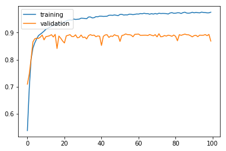

```python
plt.plot(history.history['acc'])
plt.plot(history.history['val_acc'])
plt.legend(['training', 'validation'], loc = 'upper left')
plt.show()
```

```python
results = model.evaluate(X_test, y_test)
```

```python
print('Test accuracy: ', results[1])
```

```
Test accuracy:  0.86876
```